# Creating Publication-Quality Graphics in R

## Challenge (5min)

- Problem
- Solution

**Create a figure showing how *life expectancy* changes as a function of *time***

- Colour datapoints by continent, and use two layers:
  - a line plot, grouping points by country
  - a scatterplot showing each data point, with 35% opacity

```r
p <- ggplot(data=gapminder, aes(x=year, y=lifeExp, color=continent))
p + geom_line(aes(group=country)) + geom_point(alpha=0.35)
```

## Transformations and `scale`s

**Data transformations are handled with `scale` layers**

- axis scaling (log scales)
- colour scaling (changing palettes)

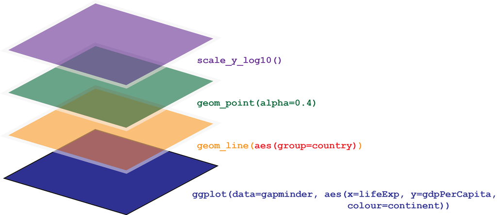

Figure 10: Axis scales, palette scales, etc. are added as layers

**INTERACTIVE DEMO**

## Statistics layers

**Some `geom` layers transform the dataset**

- Usually this is a data summary (e.g. smoothing or binning, or fitting a model)

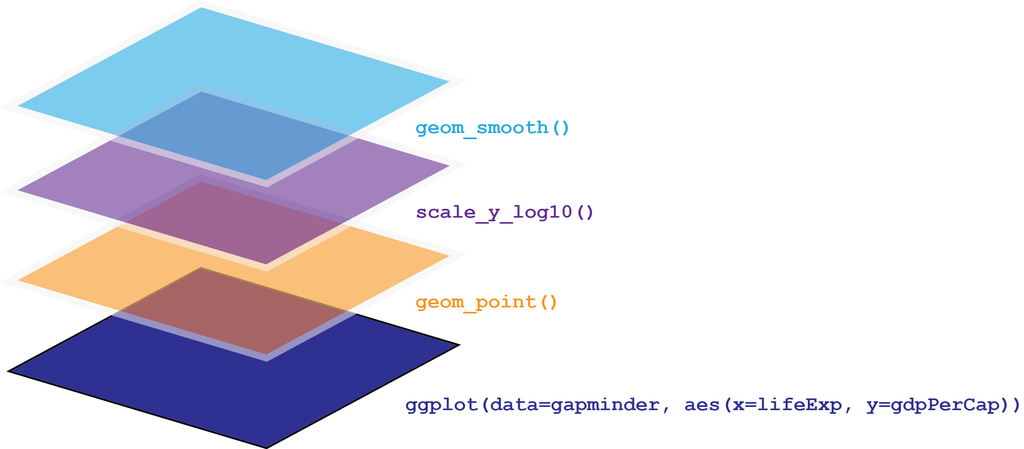

Figure 11: Statistical transformations are also added as layers

**INTERACTIVE DEMO**

## Multi-panel figures

**Comparisons can be clearer with multiple panels**

- *facets*
- “small multiples plots”

Use the `facet_wrap()` layer to generate grids of plots

**INTERACTIVE DEMO**

```r
# Compare life expectancy over time by continent
p <- ggplot(data=gapminder, aes(x=year, y=lifeExp, colour=continent,
                                group=country))
p <- p + geom_line() + scale_y_log10()
p + facet_wrap(~continent)
```

## Challenge (5min)

- Problem
- Solution

**Create a scatterplot and contour densities of GDP per capita against population size**

- Fill datapoint colour by continent?

**ADVANCED CHALLENGE**

Transform the *x* axis to better visualise data spread, and use facets to panel density plots by year.

```r
p <- ggplot(data=gapminder, aes(x=pop, y=gdpPercap))
p <- p + geom_point(alpha=0.8, aes(color=continent))
p <- p + scale_y_log10() + scale_x_log10()
p + geom_density_2d(alpha=0.5) + facet_wrap(~year)
```